# CodeEE6791B__190010058_RohitVartak

```python
import IPython
import numpy as np
from math import pi
import scipy
from scipy import signal
from matplotlib import pyplot as plt
from scipy.io.wavfile import write
```

```python
def getFilterDenCoef(F1, B1, Fs):
    #gives the coeffiecients of the denominator of the transfer function i.e
    # denominator is 1 -2*r*np.cos(theta)(z^-1) + r*r(z^-2) so returns the array [1, -2*r*np.cos(theta), r*r]
    r, theta = np.exp(-b1*pi*T), 2*pi*f1*T
    return np.array([1, -2*r*np.cos(theta), r*r])
def computeImpRes(ini, samples, r, theta):
    #computing the impulse response from the difference equations
    y = np.zeros((samples, 1))
    y[0], y[1], y[2] = ini #intiliazes the  first three samples of the output according to ini(passed by user)
    for i in range(3, samples):
        y[i] = 2*r*np.cos(theta)*y[i-1] - r*r*y[i-2] #difference equation generated from H(z)
    return y
def computeResponse(x, samples, r, theta):
    #computing the impulse response from the difference equations given x(input)
    assert x.shape[0]==samples
    y = np.zeros((samples, 1))
    y[0] = x[0] #assumed casual
    y[1] = x[1] + 2*r*np.cos(theta)*y[0]
    y[2] = x[2] + 2*r*np.cos(theta)*y[1] - r*r*y[0]
    for i in range(3, samples):
        y[i] = x[i] + 2*r*np.cos(theta)*y[i-1] - r*r*y[i-2]
    return y
def triagInput(P, samples, width = 4, start = 0):
    #start = {0, 1} whether to start at 0 or the next non-zero sample
    #see the explaination of how i generated this function above!
    x = np.zeros((samples, 1))
    peaks= []
    for i in range(start, samples+start):
        if i%P==0:#peaks at the integer multiples of int(fs/f0)
            x[i] = 1 #populating the peaks
            peaks.append(i)
    for j in peaks:
        for k in range(width):
            if j-k>=0:
                x[j-k] = 1 - (k/width)#populate for values less than the peak
            if j+k<samples:
                x[j+k] = 1 - (k/width)#populate for values above than the peak
    return x
```

```python
def computeDFTAtFreq(x, dftSize, k):
  assert x.shape[0]==dftSize
  phasors = np.array([np.exp((-1j*2*pi*k*m)/dftSize) for m in range(x.shape[0])], dtype = 'complex_')
  return np.sum(x*phasors)
```

```python
def computeDFT(x, dftSize):
  assert x.shape[0]==dftSize
  dft = np.zeros(shape = dftSize,dtype = 'complex_')
  for i in range(dftSize):
    dft[i] = computeDFTAtFreq(x, dftSize, i)
  return dft
```

```python
f1 = 300 #formant frequency
f2 = 870
f3 = 2240
b1 = 100 #bandwith
fs = 16000 #sampling frequency
T = 1.0/fs #samples
F0 = 220
dur = 1
timeSpace = np.linspace(0, dur, int(dur*fs))
P = fs//F0
samp = len(timeSpace)
width = 2#no of samples on either side of the peak for the triangular input
r1 = np.exp(-b1*pi*T)
theta1 = 2*pi*f1*T
r2 = np.exp(-b1*pi*T)
theta2 = 2*pi*f2*T
r3 = np.exp(-b1*pi*T)
theta3 = 2*pi*f3*T
y1 = computeResponse(triagInput(P, samp, width = width), samp, r1, theta1)
y2 = computeResponse(y1, samp, r2, theta2)
data = computeResponse(y2, samp, r3, theta3)
data = np.array([data[i][0] for i in range(data.shape[0])])
```

# Code for specific window

## At 120Hz

```python
f1 = 300 #formant frequency
f2 = 870
f3 = 2240
b1 = 100 #bandwith
fs = 16000 #sampling frequency
T = 1.0/fs #samples
F0 = 120
dur = 2
timeSpace = np.linspace(0, dur, int(dur*fs))
P = fs//F0
samp = len(timeSpace)
width = 2#no of samples on either side of the peak for the triangular input
r1 = np.exp(-b1*pi*T)
theta1 = 2*pi*f1*T
r2 = np.exp(-b1*pi*T)
theta2 = 2*pi*f2*T
r3 = np.exp(-b1*pi*T)
theta3 = 2*pi*f3*T
y1 = computeResponse(triagInput(P, samp, width = width), samp, r1, theta1)
y2 = computeResponse(y1, samp, r2, theta2)
data = computeResponse(y2, samp, r3, theta3)
data = np.array([data[i][0] for i in range(data.shape[0])])
```

### Defining the window sizes and dft size

```python
windowSize = [0.005, 0.01, 0.02, 0.04]
dftSize = [30000 for window in windowSize]
```

### 5ms rectangular and Hamming window @120 Hz

```python
i = 0
delta = (int(windowSize[i]*fs) - P)//2
#sampling the signal at the centre of the period
dataWindowedh = data[10*P-delta:11*P+ delta+1]*np.hamming(int(windowSize[i]*fs)) #choosing the hamming window
#dataWindowedh = np.append(dataWindowedh, np.zeros(shape = dftSize[i] - dataWindowedh.shape[0]))
#windowedDFT = computeDFT(dataWindowed, dftSize[i])#the numpy implementation is much faster and hence i use that
#windowedDFT = np.abs(windowedDFT)
windowedDFTh = np.abs(np.fft.fft(dataWindowedh, dftSize[i]))[:dftSize[i]//2]
```

```python
dataWindowedr = data[10*P-delta:11*P+ delta+1] #choosing the rectangular window
#dataWindowedr = np.append(dataWindowedr, np.zeros(shape = dftSize[i] - dataWindowedr.shape[0]))
#windowedDFT = computeDFT(dataWindowed, dftSize[i])#the numpy implementation is much faster and hence i use that
#windowedDFT = np.abs(windowedDFT)
windowedDFTr = np.abs(np.fft.fft(dataWindowedr, dftSize[i]))[:dftSize[i]//2]#finding the fft of the windowed signal
```

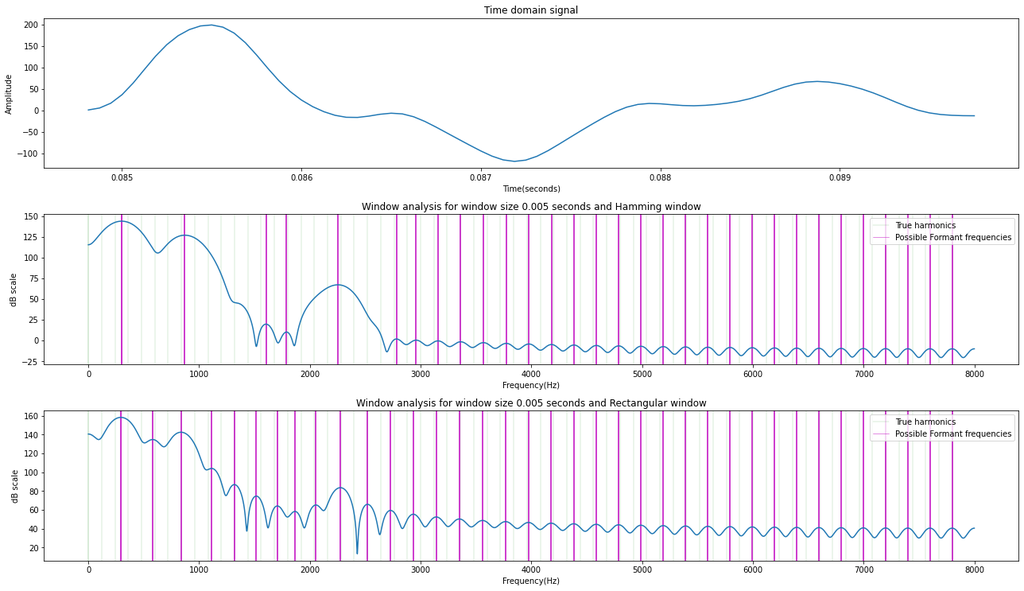

```python
fig = plt.figure()
plt.subplot(311)
#plt.plot([i/fs for i in range(10*P-delta, 11*P+ delta)], data[10*P-delta:11*P+ delta])
plt.plot([j/fs for j in range(10*P-delta,11*P+ delta+1)], data[0:int(windowSize[0]*fs)])
plt.title("Time domain signal")
plt.xlabel("Time(seconds)")
plt.ylabel("Amplitude")


plt.tight_layout(pad = 1.1)
plt.subplot(312)
fig.set_figheight(10)
fig.set_figwidth(18)
#plt.axvline(300, c= 'r', linestyle = '-', alpha = 0.4)
vlines = [i*F0 for i in range(0, int(fs/(2*F0)))]
magMaxh = scipy.signal.find_peaks(20*np.log(np.abs(windowedDFTh)))[0]*16000/30000
plt.axvline(vlines[0], c = 'g', linewidth = 0.4,alpha = 0.4)
plt.axvline(magMaxh[0], c = 'm', linewidth = 0.5,alpha = 0.9)
for i in vlines:
  plt.axvline(i, c = 'g', linewidth = 0.4,alpha = 0.4)

for i in magMaxh:
  plt.axvline(i, c = 'm')
#plt.plot(freqDFTh, 20*np.log(np.abs(windowedDFTh)))
plt.plot(np.arange(0, fs/2, fs/dftSize[0])[0:], 20*np.log(np.abs(windowedDFTh)))


#plt.axvline(870, c= 'r', linestyle = '-', alpha = 0.4)
#plt.axvline(2240, c= 'r', linestyle = '-', alpha = 0.4)
plt.title(f"Window analysis for window size {windowSize[0]} seconds and Hamming window")
plt.xlabel("Frequency(Hz)")
plt.ylabel("dB scale")
plt.legend(["True harmonics", "Possible Formant frequencies"])
plt.tight_layout(pad = 1.1)

plt.subplot(313)
fig.set_figheight(10)
fig.set_figwidth(18)
#plt.axvline(300, c= 'r', linestyle = '-', alpha = 0.4)
vlines = [i*F0 for i in range(0, int(fs/(2*F0)))]
magMaxr = scipy.signal.find_peaks(20*np.log(np.abs(windowedDFTr)))[0]*16000/30000
plt.axvline(vlines[0], c = 'g', linewidth = 0.4,alpha = 0.4)
plt.axvline(magMaxr[0], c = 'm', linewidth = 0.5,alpha = 0.9)
for i in vlines:
  plt.axvline(i, c = 'g', linewidth = 0.4,alpha = 0.4)

for i in magMaxr:
  plt.axvline(i, c = 'm')
#plt.plot(freqDFTh, 20*np.log(np.abs(windowedDFTh)))
plt.plot(np.arange(0, fs/2, fs/dftSize[0])[0:], 20*np.log(np.abs(windowedDFTr)))


#plt.axvline(870, c= 'r', linestyle = '-', alpha = 0.4)
#plt.axvline(2240, c= 'r', linestyle = '-', alpha = 0.4)
plt.title(f"Window analysis for window size {windowSize[0]} seconds and Rectangular window")
plt.xlabel("Frequency(Hz)")
plt.ylabel("dB scale")
plt.legend(["True harmonics", "Possible Formant frequencies"])
```

```python
#for hamming window we have the following possible formants
scipy.signal.find_peaks(20*np.log(np.abs(windowedDFTh)))[0]*16000/30000
```

```
array([ 300.26666667,  870.93333333, 1604.26666667, 1789.33333333,
       2253.33333333, 2781.86666667, 2959.46666667, 3156.8       ,
       3361.6       , 3568.        , 3773.33333333, 3978.13333333,
       4181.86666667, 4384.53333333, 4586.66666667, 4788.8       ,
       4989.86666667, 5191.46666667, 5392.53333333, 5593.6       ,
       5794.13333333, 5995.2       , 6195.73333333, 6396.26666667,
       6596.8       , 6797.33333333, 6997.86666667, 7198.4       ,
       7398.93333333, 7598.93333333, 7799.46666667])
```

From the plot it is clear that :

1. Pitch cannot be estimated since the window is too small and does not see the period
2. F1 = 300.26667 Hz, F2 = 870.93333 Hz, F3 = 2253.33333333 Hz

```python
#for rectangular window we have the following possible formants
scipy.signal.find_peaks(20*np.log(np.abs(windowedDFTr)))[0]*16000/30000
```

```
array([ 293.86666667,  580.26666667,  836.26666667, 1112.53333333,
       1318.4       , 1516.26666667, 1706.13333333, 1865.6       ,
       2054.4       , 2275.2       , 2520.53333333, 2728.        ,
       2934.4       , 3141.33333333, 3349.86666667, 3558.93333333,
       3766.93333333, 3973.33333333, 4178.66666667, 4382.4       ,
       4585.06666667, 4787.73333333, 4989.33333333, 5190.93333333,
       5392.        , 5593.06666667, 5794.13333333, 5994.66666667,
       6195.73333333, 6396.26666667, 6596.8       , 6797.33333333,
       6997.86666667, 7198.4       , 7398.93333333, 7598.93333333,
       7799.46666667])
```

From the plot it is clear that :

1. Pitch cannot be estimated since the window is too small and does not see the period
2. F1 = 293.86666667 Hz, F2 = 836.26666667 Hz, F3 = 2275.2 Hz

### 10ms rectangular and Hamming window @120 Hz

```python
i = 1
delta = (int(windowSize[i]*fs) - P)//2
#sampling the signal at the centre of the period
dataWindowedh = data[10*P-delta:11*P+ delta+1]*np.hamming(int(windowSize[i]*fs)) #choosing the hamming window
#dataWindowedh = np.append(dataWindowedh, np.zeros(shape = dftSize[i] - dataWindowedh.shape[0]))
#windowedDFT = computeDFT(dataWindowed, dftSize[i])#the numpy implementation is much faster and hence i use that
#windowedDFT = np.abs(windowedDFT)
windowedDFTh = np.abs(np.fft.fft(dataWindowedh, dftSize[i]))[:dftSize[i]//2]
```

```python
dataWindowedr = data[10*P-delta:11*P+ delta+1] #choosing the rectangular window
#dataWindowedr = np.append(dataWindowedr, np.zeros(shape = dftSize[i] - dataWindowedr.shape[0]))
#windowedDFT = computeDFT(dataWindowed, dftSize[i])#the numpy implementation is much faster and hence i use that
#windowedDFT = np.abs(windowedDFT)
windowedDFTr = np.abs(np.fft.fft(dataWindowedr, dftSize[i]))[:dftSize[i]//2]#finding the fft of the windowed signal
```

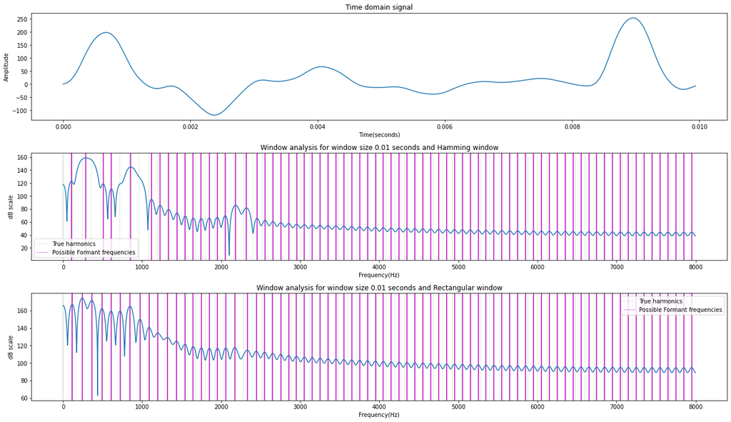

```python
fig = plt.figure()
plt.subplot(311)
#plt.plot([i/fs for i in range(10*P-delta, 11*P+ delta)], data[10*P-delta:11*P+ delta])
plt.plot([j/fs for j in range(0, int(windowSize[1]*fs))], data[0:int(windowSize[1]*fs)])
plt.title("Time domain signal")
plt.xlabel("Time(seconds)")
plt.ylabel("Amplitude")


plt.tight_layout(pad = 1.1)
plt.subplot(312)
fig.set_figheight(10)
fig.set_figwidth(18)
#plt.axvline(300, c= 'r', linestyle = '-', alpha = 0.4)
vlines = [i*F0 for i in range(0, int(fs/(2*F0)))]
magMaxh = scipy.signal.find_peaks(20*np.log(np.abs(windowedDFTh)))[0]*16000/30000
plt.axvline(vlines[0], c = 'g', linewidth = 0.4,alpha = 0.4)
plt.axvline(magMaxh[0], c = 'm', linewidth = 0.5,alpha = 0.9)
for i in vlines:
  plt.axvline(i, c = 'g', linewidth = 0.4,alpha = 0.4)

for i in magMaxh:
  plt.axvline(i, c = 'm')
#plt.plot(freqDFTh, 20*np.log(np.abs(windowedDFTh)))
plt.plot(np.arange(0, fs/2, fs/dftSize[1])[0:], 20*np.log(np.abs(windowedDFTh)))


#plt.axvline(870, c= 'r', linestyle = '-', alpha = 0.4)
#plt.axvline(2240, c= 'r', linestyle = '-', alpha = 0.4)
plt.title(f"Window analysis for window size {windowSize[1]} seconds and Hamming window")
plt.xlabel("Frequency(Hz)")
plt.ylabel("dB scale")
plt.legend(["True harmonics", "Possible Formant frequencies"])
plt.tight_layout(pad = 1.1)

plt.subplot(313)
fig.set_figheight(10)
fig.set_figwidth(18)
#plt.axvline(300, c= 'r', linestyle = '-', alpha = 0.4)
vlines = [i*F0 for i in range(0, int(fs/(2*F0)))]
magMaxr = scipy.signal.find_peaks(20*np.log(np.abs(windowedDFTr)))[0]*16000/30000
plt.axvline(vlines[0], c = 'g', linewidth = 0.4,alpha = 0.4)
plt.axvline(magMaxr[0], c = 'm', linewidth = 0.5,alpha = 0.9)
for i in vlines:
  plt.axvline(i, c = 'g', linewidth = 0.4,alpha = 0.4)

for i in magMaxr:
  plt.axvline(i, c = 'm')
#plt.plot(freqDFTh, 20*np.log(np.abs(windowedDFTh)))
plt.plot(np.arange(0, fs/2, fs/dftSize[1])[0:], 20*np.log(np.abs(windowedDFTr)))


#plt.axvline(870, c= 'r', linestyle = '-', alpha = 0.4)
#plt.axvline(2240, c= 'r', linestyle = '-', alpha = 0.4)
plt.title(f"Window analysis for window size {windowSize[1]} seconds and Rectangular window")
plt.xlabel("Frequency(Hz)")
plt.ylabel("dB scale")
plt.legend(["True harmonics", "Possible Formant frequencies"])
```

```python
#for hamming window we have the following possible formants
(scipy.signal.find_peaks(20*np.log(np.abs(windowedDFTh)))[0]*16000/30000)
```

```
array([ 104.53333333,  285.33333333,  506.13333333,  610.66666667,
        856.53333333, 1118.4       , 1227.2       , 1334.4       ,
       1440.53333333, 1544.53333333, 1645.86666667, 1746.66666667,
       1848.        , 1949.33333333, 2050.66666667, 2182.93333333,
       2319.46666667, 2452.26666667, 2554.13333333, 2653.86666667,
       2754.13333333, 2853.86666667, 2953.6       , 3052.8       ,
       3152.53333333, 3251.73333333, 3351.46666667, 3451.2       ,
       3550.93333333, 3650.66666667, 3750.93333333, 3850.66666667,
       3950.93333333, 4050.66666667, 4150.93333333, 4250.66666667,
       4350.93333333, 4450.66666667, 4550.93333333, 4650.66666667,
       4750.93333333, 4850.66666667, 4950.4       , 5050.66666667,
       5150.4       , 5250.66666667, 5350.4       , 5450.66666667,
       5550.4       , 5650.66666667, 5750.4       , 5850.66666667,
       5950.4       , 6050.13333333, 6150.4       , 6250.13333333,
       6350.4       , 6450.13333333, 6550.4       , 6650.13333333,
       6750.4       , 6850.13333333, 6950.4       , 7050.13333333,
       7150.4       , 7250.13333333, 7349.86666667, 7450.13333333,
       7549.86666667, 7650.13333333, 7749.86666667, 7850.13333333,
       7949.86666667])
```

From the plot it is clear that :

1. Pitch can be estimated since the window is large enought see the period F0 ~ 100 Hz
2. F1 = 285.3333333333333 Hz, F2 = 856.5333333333333 Hz, F3 = 2182.933333333333 Hz

```python
#for rectangular window we have the following possible formants
(scipy.signal.find_peaks(20*np.log(np.abs(windowedDFTr)))[0]*16000/30000)
```

```
array([ 114.66666667,  242.13333333,  362.66666667,  491.2       ,
        606.4       ,  721.06666667,  845.33333333,  971.73333333,
       1086.93333333, 1199.46666667, 1319.46666667, 1434.13333333,
       1541.33333333, 1645.33333333, 1747.73333333, 1850.13333333,
       1953.06666667, 2058.13333333, 2171.2       , 2330.13333333,
       2444.26666667, 2548.8       , 2650.66666667, 2752.        ,
       2852.8       , 2952.53333333, 3052.8       , 3152.53333333,
       3251.73333333, 3351.46666667, 3451.2       , 3550.93333333,
       3651.2       , 3750.93333333, 3850.66666667, 3950.93333333,
       4050.66666667, 4150.93333333, 4251.2       , 4350.93333333,
       4450.66666667, 4550.93333333, 4650.66666667, 4750.93333333,
       4850.66666667, 4950.93333333, 5050.66666667, 5150.4       ,
       5250.66666667, 5350.4       , 5450.66666667, 5550.4       ,
       5650.66666667, 5750.4       , 5850.66666667, 5950.4       ,
       6050.66666667, 6150.4       , 6250.13333333, 6350.4       ,
       6450.13333333, 6550.4       , 6650.13333333, 6750.4       ,
       6850.13333333, 6950.4       , 7050.13333333, 7150.4       ,
       7250.13333333, 7349.86666667, 7450.13333333, 7549.86666667,
       7650.13333333, 7749.86666667, 7850.13333333, 7949.86666667])
```

### 20ms rectangular and Hamming window @120 Hz

```python
i = 2
delta = (int(windowSize[i]*fs) - P)//2
#sampling the signal at the centre of the period
dataWindowedh = data[10*P-delta:11*P+ delta+1]*np.hamming(int(windowSize[i]*fs)) #choosing the hamming window
#dataWindowedh = np.append(dataWindowedh, np.zeros(shape = dftSize[i] - dataWindowedh.shape[0]))
#windowedDFT = computeDFT(dataWindowed, dftSize[i])#the numpy implementation is much faster and hence i use that
#windowedDFT = np.abs(windowedDFT)
windowedDFTh = np.abs(np.fft.fft(dataWindowedh, dftSize[i]))[:dftSize[i]//2]
```

```python
dataWindowedr = data[10*P-delta:11*P+ delta+1] #choosing the rectangular window
#dataWindowedr = np.append(dataWindowedr, np.zeros(shape = dftSize[i] - dataWindowedr.shape[0]))
#windowedDFT = computeDFT(dataWindowed, dftSize[i])#the numpy implementation is much faster and hence i use that
#windowedDFT = np.abs(windowedDFT)
windowedDFTr = np.abs(np.fft.fft(dataWindowedr, dftSize[i]))[:dftSize[i]//2]#finding the fft of the windowed signal
```

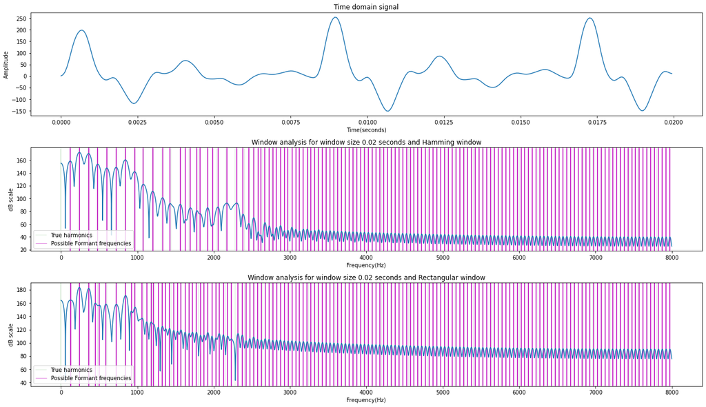

```python
fig = plt.figure()
plt.subplot(311)
#plt.plot([i/fs for i in range(10*P-delta, 11*P+ delta)], data[10*P-delta:11*P+ delta])
plt.plot([j/fs for j in range(0, int(windowSize[2]*fs))], data[0:int(windowSize[2]*fs)])
plt.title("Time domain signal")
plt.xlabel("Time(seconds)")
plt.ylabel("Amplitude")


plt.tight_layout(pad = 1.1)
plt.subplot(312)
fig.set_figheight(10)
fig.set_figwidth(18)
#plt.axvline(300, c= 'r', linestyle = '-', alpha = 0.4)
vlines = [i*F0 for i in range(0, int(fs/(2*F0)))]
magMaxh = scipy.signal.find_peaks(20*np.log(np.abs(windowedDFTh)))[0]*16000/30000
plt.axvline(vlines[0], c = 'g', linewidth = 0.4,alpha = 0.4)
plt.axvline(magMaxh[0], c = 'm', linewidth = 0.5,alpha = 0.9)
for i in vlines:
  plt.axvline(i, c = 'g', linewidth = 0.4,alpha = 0.4)

for i in magMaxh:
  plt.axvline(i, c = 'm')
#plt.plot(freqDFTh, 20*np.log(np.abs(windowedDFTh)))
plt.plot(np.arange(0, fs/2, fs/dftSize[2])[0:], 20*np.log(np.abs(windowedDFTh)))


#plt.axvline(870, c= 'r', linestyle = '-', alpha = 0.4)
#plt.axvline(2240, c= 'r', linestyle = '-', alpha = 0.4)
plt.title(f"Window analysis for window size {windowSize[2]} seconds and Hamming window")
plt.xlabel("Frequency(Hz)")
plt.ylabel("dB scale")
plt.legend(["True harmonics", "Possible Formant frequencies"])
plt.tight_layout(pad = 1.1)

plt.subplot(313)
fig.set_figheight(10)
fig.set_figwidth(18)
#plt.axvline(300, c= 'r', linestyle = '-', alpha = 0.4)
vlines = [i*F0 for i in range(0, int(fs/(2*F0)))]
magMaxr = scipy.signal.find_peaks(20*np.log(np.abs(windowedDFTr)))[0]*16000/30000
plt.axvline(vlines[0], c = 'g', linewidth = 0.4,alpha = 0.4)
plt.axvline(magMaxr[0], c = 'm', linewidth = 0.5,alpha = 0.9)
for i in vlines:
  plt.axvline(i, c = 'g', linewidth = 0.4,alpha = 0.4)

for i in magMaxr:
  plt.axvline(i, c = 'm')
#plt.plot(freqDFTh, 20*np.log(np.abs(windowedDFTh)))
plt.plot(np.arange(0, fs/2, fs/dftSize[2])[0:], 20*np.log(np.abs(windowedDFTr)))


#plt.axvline(870, c= 'r', linestyle = '-', alpha = 0.4)
#plt.axvline(2240, c= 'r', linestyle = '-', alpha = 0.4)
plt.title(f"Window analysis for window size {windowSize[2]} seconds and Rectangular window")
plt.xlabel("Frequency(Hz)")
plt.ylabel("dB scale")
plt.legend(["True harmonics", "Possible Formant frequencies"])
```

```python
#for hamming window we have the following possible formants
(scipy.signal.find_peaks(20*np.log(np.abs(windowedDFTh)))[0]*16000/30000)
```

```
array([ 121.06666667,  240.53333333,  361.6       ,  480.53333333,
        599.46666667,  722.66666667,  842.66666667,  963.73333333,
       1077.86666667, 1200.53333333, 1330.13333333, 1428.8       ,
       1562.13333333, 1630.93333333, 1695.46666667, 1780.8       ,
       1824.        , 1920.53333333, 1984.53333333, 2055.46666667,
       2172.26666667, 2301.33333333, 2384.53333333, 2460.26666667,
       2524.26666667, 2582.4       , 2617.06666667, 2671.46666667,
       2728.        , 2772.8       , 2821.33333333, 2875.73333333,
       2925.33333333, 2972.26666667, 3024.53333333, 3075.73333333,
       3123.2       , 3173.86666667, 3225.6       , 3274.13333333,
       3323.73333333, 3374.93333333, 3424.53333333, 3473.6       ,
       3524.8       , 3574.93333333, 3624.        , 3674.13333333,
       3724.8       , 3774.4       , 3824.53333333, 3874.66666667,
       3924.8       , 3974.4       , 4024.53333333, 4074.66666667,
       4124.26666667, 4174.4       , 4225.06666667, 4274.66666667,
       4324.26666667, 4374.93333333, 4424.53333333, 4474.66666667,
       4524.8       , 4574.93333333, 4624.53333333, 4674.66666667,
       4724.8       , 4774.93333333, 4824.53333333, 4874.66666667,
       4924.8       , 4974.93333333, 5024.53333333, 5074.66666667,
       5124.8       , 5174.93333333, 5225.06666667, 5274.66666667,
       5324.8       , 5374.93333333, 5425.06666667, 5474.66666667,
       5524.8       , 5574.93333333, 5624.53333333, 5674.66666667,
       5724.8       , 5774.93333333, 5825.06666667, 5874.66666667,
       5924.8       , 5974.93333333, 6025.06666667, 6074.66666667,
       6124.8       , 6174.93333333, 6225.06666667, 6274.66666667,
       6324.8       , 6374.93333333, 6425.06666667, 6474.66666667,
       6524.8       , 6574.93333333, 6625.06666667, 6674.66666667,
       6724.8       , 6774.93333333, 6825.06666667, 6874.66666667,
       6924.8       , 6974.93333333, 7025.06666667, 7075.2       ,
       7124.8       , 7174.93333333, 7225.06666667, 7275.2       ,
       7324.8       , 7374.93333333, 7425.06666667, 7475.2       ,
       7524.8       , 7574.93333333, 7625.06666667, 7675.2       ,
       7724.8       , 7774.93333333, 7825.06666667, 7875.2       ,
       7924.8       , 7974.93333333])
```

From the plot it is clear that :

1. Pitch can be estimated since the window is large enought see the period F0 ~ 125 Hz [8 peaks in 0 Hz to 1000 Hz]
2. F1 = 240.53333333 Hz, F2 = 842.66666667 Hz, F3 = 2172.26666667 Hz

```python
#for rectangular window we have the following possible formants
(scipy.signal.find_peaks(20*np.log(np.abs(windowedDFTr)))[0]*16000/30000)
```

```
array([ 125.33333333,  240.        ,  363.2       ,  448.53333333,
        502.4       ,  588.26666667,  725.86666667,  845.86666667,
        921.6       ,  970.13333333, 1062.4       , 1122.66666667,
       1180.8       , 1211.2       , 1273.06666667, 1328.        ,
       1371.73333333, 1421.86666667, 1476.26666667, 1526.4       ,
       1571.2       , 1625.06666667, 1677.86666667, 1722.13333333,
       1774.4       , 1827.73333333, 1874.13333333, 1923.2       ,
       1977.06666667, 2028.8       , 2071.46666667, 2126.93333333,
       2183.46666667, 2231.46666667, 2318.4       , 2374.4       ,
       2424.53333333, 2472.        , 2523.73333333, 2574.4       ,
       2623.46666667, 2673.6       , 2724.26666667, 2774.4       ,
       2824.        , 2874.13333333, 2924.26666667, 2973.86666667,
       3024.53333333, 3074.66666667, 3124.26666667, 3174.4       ,
       3224.53333333, 3274.66666667, 3324.26666667, 3374.4       ,
       3424.53333333, 3474.66666667, 3524.26666667, 3574.4       ,
       3624.53333333, 3674.66666667, 3724.8       , 3774.4       ,
       3824.53333333, 3874.66666667, 3924.8       , 3974.4       ,
       4024.53333333, 4074.66666667, 4124.8       , 4174.4       ,
       4224.53333333, 4274.66666667, 4324.8       , 4374.93333333,
       4424.53333333, 4474.66666667, 4524.8       , 4574.93333333,
       4624.53333333, 4674.66666667, 4724.8       , 4774.93333333,
       4824.53333333, 4874.66666667, 4924.8       , 4974.93333333,
       5024.53333333, 5074.66666667, 5124.8       , 5174.93333333,
       5224.53333333, 5274.66666667, 5324.8       , 5374.93333333,
       5425.06666667, 5474.66666667, 5524.8       , 5574.93333333,
       5625.06666667, 5674.66666667, 5724.8       , 5774.93333333,
       5825.06666667, 5874.66666667, 5924.8       , 5974.93333333,
       6025.06666667, 6074.66666667, 6124.8       , 6174.93333333,
       6225.06666667, 6274.66666667, 6324.8       , 6374.93333333,
       6425.06666667, 6474.66666667, 6524.8       , 6574.93333333,
       6625.06666667, 6674.66666667, 6724.8       , 6774.93333333,
       6825.06666667, 6874.66666667, 6924.8       , 6974.93333333,
       7025.06666667, 7075.2       , 7124.8       , 7174.93333333,
       7225.06666667, 7275.2       , 7324.8       , 7374.93333333,
       7425.06666667, 7475.2       , 7524.8       , 7574.93333333,
       7625.06666667, 7675.2       , 7724.8       , 7774.93333333,
       7825.06666667, 7875.2       , 7924.8       , 7974.93333333])
```

### 40ms rectangular and Hamming window @120 Hz

```python
i = 3
delta = (int(windowSize[i]*fs) - P)//2
#sampling the signal at the centre of the period
dataWindowedh = data[10*P-delta:11*P+ delta+1]*np.hamming(int(windowSize[i]*fs)) #choosing the hamming window
#dataWindowedh = np.append(dataWindowedh, np.zeros(shape = dftSize[i] - dataWindowedh.shape[0]))
#windowedDFT = computeDFT(dataWindowed, dftSize[i])#the numpy implementation is much faster and hence i use that
#windowedDFT = np.abs(windowedDFT)
windowedDFTh = np.abs(np.fft.fft(dataWindowedh, dftSize[i]))[:dftSize[i]//2]
```

```python
dataWindowedr = data[10*P-delta:11*P+ delta+1] #choosing the rectangular window
#dataWindowedr = np.append(dataWindowedr, np.zeros(shape = dftSize[i] - dataWindowedr.shape[0]))
#windowedDFT = computeDFT(dataWindowed, dftSize[i])#the numpy implementation is much faster and hence i use that
#windowedDFT = np.abs(windowedDFT)
windowedDFTr = np.abs(np.fft.fft(dataWindowedr, dftSize[i]))[:dftSize[i]//2]#finding the fft of the windowed signal
```

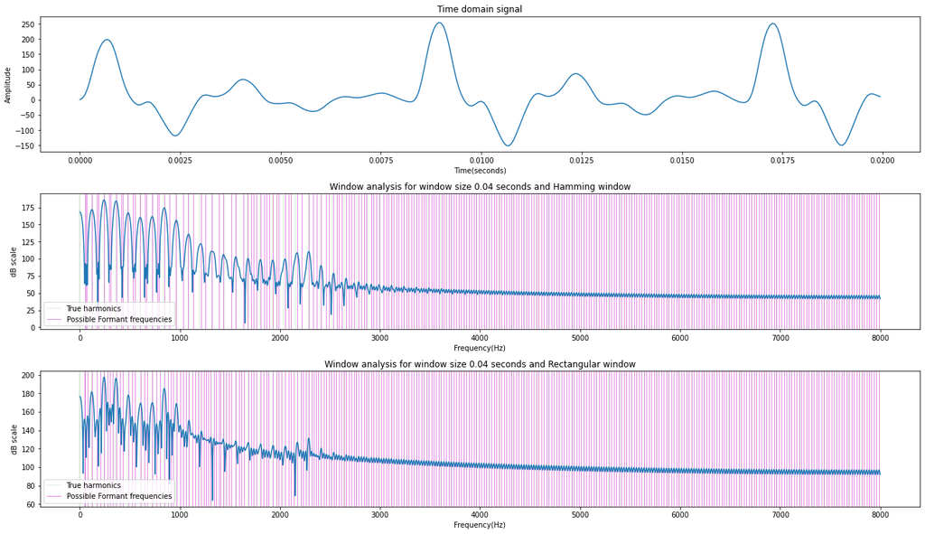

```python
fig = plt.figure()
plt.subplot(311)
#plt.plot([i/fs for i in range(10*P-delta, 11*P+ delta)], data[10*P-delta:11*P+ delta])
plt.plot([j/fs for j in range(0, int(windowSize[2]*fs))], data[0:int(windowSize[2]*fs)])
plt.title("Time domain signal")
plt.xlabel("Time(seconds)")
plt.ylabel("Amplitude")


plt.tight_layout(pad = 1.1)
plt.subplot(312)
fig.set_figheight(10)
fig.set_figwidth(18)
#plt.axvline(300, c= 'r', linestyle = '-', alpha = 0.4)
vlines = [i*F0 for i in range(0, int(fs/(2*F0)))]
magMaxh = scipy.signal.find_peaks(20*np.log(np.abs(windowedDFTh)))[0]*16000/30000
plt.axvline(vlines[0], c = 'g', linewidth = 0.4,alpha = 0.4)
plt.axvline(magMaxh[0], c = 'm', linewidth = 0.5,alpha = 0.9)
for i in vlines:
  plt.axvline(i, c = 'g', linewidth = 0.4,alpha = 0.4)

for i in magMaxh:
  plt.axvline(i, c = 'm', linewidth = 0.5,alpha = 0.9)
#plt.plot(freqDFTh, 20*np.log(np.abs(windowedDFTh)))
plt.plot(np.arange(0, fs/2, fs/dftSize[3])[0:], 20*np.log(np.abs(windowedDFTh)))


#plt.axvline(870, c= 'r', linestyle = '-', alpha = 0.4)
#plt.axvline(2240, c= 'r', linestyle = '-', alpha = 0.4)
plt.title(f"Window analysis for window size {windowSize[3]} seconds and Hamming window")
plt.xlabel("Frequency(Hz)")
plt.ylabel("dB scale")
plt.legend(["True harmonics", "Possible Formant frequencies"])
plt.tight_layout(pad = 1.1)

plt.subplot(313)
fig.set_figheight(10)
fig.set_figwidth(18)
#plt.axvline(300, c= 'r', linestyle = '-', alpha = 0.4)
vlines = [i*F0 for i in range(0, int(fs/(2*F0)))]
magMaxr = scipy.signal.find_peaks(20*np.log(np.abs(windowedDFTr)))[0]*16000/30000
plt.axvline(vlines[0], c = 'g', linewidth = 0.4,alpha = 0.4)
plt.axvline(magMaxr[0], c = 'm', linewidth = 0.5,alpha = 0.9)
for i in vlines:
  plt.axvline(i, c = 'g', linewidth = 0.4,alpha = 0.4)

for i in magMaxr:
  plt.axvline(i, c = 'm', linewidth = 0.5,alpha = 0.9)
#plt.plot(freqDFTh, 20*np.log(np.abs(windowedDFTh)))
plt.plot(np.arange(0, fs/2, fs/dftSize[3])[0:], 20*np.log(np.abs(windowedDFTr)))


#plt.axvline(870, c= 'r', linestyle = '-', alpha = 0.4)
#plt.axvline(2240, c= 'r', linestyle = '-', alpha = 0.4)
plt.title(f"Window analysis for window size {windowSize[3]} seconds and Rectangular window")
plt.xlabel("Frequency(Hz)")
plt.ylabel("dB scale")
plt.legend(["True harmonics", "Possible Formant frequencies"])
```

```python
#for hamming window we have the following possible formants
(scipy.signal.find_peaks(20*np.log(np.abs(windowedDFTh)))[0]*16000/30000)
```

```
array([  52.26666667,   68.26666667,  120.        ,  171.73333333,
        186.66666667,  240.53333333,  294.4       ,  306.66666667,
        361.06666667,  413.86666667,  429.86666667,  482.13333333,
        531.73333333,  548.8       ,  602.13333333,  652.26666667,
        668.8       ,  722.13333333,  773.33333333,  787.73333333,
        842.66666667,  894.93333333,  963.2       , 1033.6       ,
       1085.33333333, 1133.86666667, 1208.        , 1257.06666667,
       1315.73333333, 1387.2       , 1435.2       , 1513.06666667,
       1557.33333333, 1637.86666667, 1681.06666667, 1713.06666667,
       1738.13333333, 1763.2       , 1804.26666667, 1840.53333333,
       1862.93333333, 1889.6       , 1927.46666667, 1965.33333333,
       1987.2       , 2050.13333333, 2089.6       , 2110.4       ,
       2169.6       , 2213.33333333, 2286.93333333, 2330.66666667,
       2369.06666667, 2410.13333333, 2462.93333333, 2491.73333333,
       2534.93333333, 2566.93333333, 2587.73333333, 2615.46666667,
       2660.8       , 2689.06666667, 2712.53333333, 2740.26666667,
       2786.13333333, 2812.8       , 2837.33333333, 2864.53333333,
       2911.46666667, 2937.6       , 2962.13333333, 2989.33333333,
       3036.8       , 3062.4       , 3086.93333333, 3114.13333333,
       3134.4       , 3162.13333333, 3187.2       , 3211.73333333,
       3238.93333333, 3260.8       , 3286.93333333, 3312.        ,
       3336.53333333, 3363.73333333, 3386.66666667, 3412.26666667,
       3437.33333333, 3461.33333333, 3488.53333333, 3512.        ,
       3537.06666667, 3562.13333333, 3586.66666667, 3613.33333333,
       3636.8       , 3662.4       , 3687.46666667, 3711.46666667,
       3738.13333333, 3762.13333333, 3787.2       , 3812.26666667,
       3836.8       , 3862.93333333, 3887.46666667, 3912.53333333,
       3937.6       , 3961.6       , 3987.73333333, 4012.26666667,
       4037.33333333, 4062.4       , 4086.93333333, 4112.53333333,
       4137.6       , 4162.13333333, 4187.73333333, 4211.73333333,
       4237.33333333, 4262.4       , 4287.46666667, 4312.53333333,
       4337.06666667, 4362.66666667, 4387.2       , 4412.26666667,
       4437.33333333, 4461.86666667, 4487.46666667, 4512.53333333,
       4537.6       , 4562.66666667, 4587.2       , 4612.26666667,
       4637.33333333, 4662.4       , 4687.46666667, 4712.        ,
       4737.6       , 4762.13333333, 4787.2       , 4812.26666667,
       4837.33333333, 4862.4       , 4887.46666667, 4912.53333333,
       4937.6       , 4962.13333333, 4987.2       , 5012.26666667,
       5037.33333333, 5062.4       , 5087.46666667, 5112.53333333,
       5137.6       , 5162.66666667, 5187.2       , 5212.26666667,
```

[output cut: 13 more lines]

```
       6537.6       , 6562.66666667, 6587.2       , 6612.26666667,
       6637.33333333, 6662.4       , 6687.46666667, 6712.53333333,
       6737.6       , 6762.66666667, 6787.2       , 6812.26666667,
       6837.33333333, 6862.4       , 6887.46666667, 6912.53333333,
       6937.6       , 6962.66666667, 6987.73333333, 7012.26666667,
       7037.33333333, 7062.4       , 7087.46666667, 7112.53333333,
       7137.6       , 7162.66666667, 7187.73333333, 7212.26666667,
       7237.33333333, 7262.4       , 7287.46666667, 7312.53333333,
       7337.6       , 7362.66666667, 7387.73333333, 7412.26666667,
       7437.33333333, 7462.4       , 7487.46666667, 7512.53333333,
       7537.6       , 7562.66666667, 7587.73333333, 7612.26666667,
       7637.33333333, 7662.4       , 7687.46666667, 7712.53333333,
       7737.6       , 7762.66666667, 7787.73333333, 7812.26666667,
       7837.33333333, 7862.4       , 7887.46666667, 7912.53333333,
       7937.6       , 7962.66666667, 7987.73333333])
```

From the plot it is clear that :

1. Pitch can be estimated since the window is large enought see the period F0 ~ 125 Hz [8 major peaks in 1000 Hz to 2000Hz]
2. F1 = 240.53333333 Hz, F2 = 842.66666667 Hz, F3 = 2169.6 Hz

```python
#for rectangular window we have the following possible formants
(scipy.signal.find_peaks(20*np.log(np.abs(windowedDFTr)))[0]*16000/30000)
```

```
array([  45.86666667,   78.4       ,  118.93333333,  171.73333333,
        202.66666667,  241.6       ,  277.33333333,  301.86666667,
        325.86666667,  360.53333333,  398.4       ,  426.66666667,
        484.26666667,  521.06666667,  550.93333333,  606.4       ,
        644.26666667,  675.2       ,  723.2       ,  766.4       ,
        801.06666667,  843.73333333,  880.53333333,  907.2       ,
        932.8       ,  963.73333333, 1002.13333333, 1031.46666667,
       1058.66666667, 1089.6       , 1123.2       , 1156.26666667,
       1183.46666667, 1214.4       , 1241.6       , 1258.13333333,
       1281.6       , 1307.73333333, 1339.2       , 1364.8       ,
       1388.26666667, 1408.53333333, 1432.53333333, 1464.        ,
       1489.06666667, 1514.13333333, 1557.33333333, 1588.26666667,
       1613.33333333, 1638.93333333, 1682.13333333, 1713.06666667,
       1738.13333333, 1763.73333333, 1806.93333333, 1837.33333333,
       1862.93333333, 1888.53333333, 1931.2       , 1961.6       ,
       1987.73333333, 2013.33333333, 2054.4       , 2085.33333333,
       2111.46666667, 2137.6       , 2173.33333333, 2205.86666667,
       2232.        , 2257.06666667, 2287.46666667, 2316.8       ,
       2339.73333333, 2362.66666667, 2383.46666667, 2411.2       ,
       2438.4       , 2463.46666667, 2488.        , 2510.93333333,
       2536.53333333, 2562.66666667, 2587.73333333, 2612.8       ,
       2636.26666667, 2661.86666667, 2687.46666667, 2712.53333333,
       2737.6       , 2761.6       , 2786.66666667, 2812.26666667,
       2837.33333333, 2862.93333333, 2886.93333333, 2912.        ,
       2937.06666667, 2962.13333333, 2987.73333333, 3012.26666667,
       3037.33333333, 3062.4       , 3087.46666667, 3112.53333333,
       3137.06666667, 3162.13333333, 3187.2       , 3212.26666667,
       3237.33333333, 3262.4       , 3287.46666667, 3312.        ,
       3337.06666667, 3362.66666667, 3387.2       , 3412.26666667,
       3437.33333333, 3462.4       , 3487.46666667, 3512.53333333,
       3537.06666667, 3562.13333333, 3587.2       , 3612.26666667,
       3637.33333333, 3662.4       , 3687.46666667, 3712.        ,
       3737.6       , 3762.13333333, 3787.2       , 3812.26666667,
       3837.33333333, 3862.4       , 3887.46666667, 3912.53333333,
       3937.6       , 3962.13333333, 3987.2       , 4012.26666667,
       4037.33333333, 4062.4       , 4087.46666667, 4112.53333333,
       4137.6       , 4162.13333333, 4187.2       , 4212.26666667,
       4237.33333333, 4262.4       , 4287.46666667, 4312.53333333,
       4337.06666667, 4362.13333333, 4387.2       , 4412.26666667,
       4437.33333333, 4462.4       , 4487.46666667, 4512.53333333,
```

[output cut: 20 more lines]

```
       6537.6       , 6562.66666667, 6587.2       , 6612.26666667,
       6637.33333333, 6662.4       , 6687.46666667, 6712.53333333,
       6737.6       , 6762.66666667, 6787.2       , 6812.26666667,
       6837.33333333, 6862.4       , 6887.46666667, 6912.53333333,
       6937.6       , 6962.66666667, 6987.73333333, 7012.26666667,
       7037.33333333, 7062.4       , 7087.46666667, 7112.53333333,
       7137.6       , 7162.66666667, 7187.73333333, 7212.26666667,
       7237.33333333, 7262.4       , 7287.46666667, 7312.53333333,
       7337.6       , 7362.66666667, 7387.73333333, 7412.26666667,
       7437.33333333, 7462.4       , 7487.46666667, 7512.53333333,
       7537.6       , 7562.66666667, 7587.73333333, 7612.26666667,
       7637.33333333, 7662.4       , 7687.46666667, 7712.53333333,
       7737.6       , 7762.66666667, 7787.73333333, 7812.26666667,
       7837.33333333, 7862.4       , 7887.46666667, 7912.53333333,
       7937.6       , 7962.66666667, 7987.73333333])
```

# At 220Hz

```python
f1 = 300 #formant frequency
f2 = 870
f3 = 2240
b1 = 100 #bandwith
fs = 16000 #sampling frequency
T = 1.0/fs #samples
F0 = 220
dur = 2
timeSpace = np.linspace(0, dur, int(dur*fs))
P = fs//F0
samp = len(timeSpace)
width = 2#no of samples on either side of the peak for the triangular input
r1 = np.exp(-b1*pi*T)
theta1 = 2*pi*f1*T
r2 = np.exp(-b1*pi*T)
theta2 = 2*pi*f2*T
r3 = np.exp(-b1*pi*T)
theta3 = 2*pi*f3*T
y1 = computeResponse(triagInput(P, samp, width = width), samp, r1, theta1)
y2 = computeResponse(y1, samp, r2, theta2)
data = computeResponse(y2, samp, r3, theta3)
data = np.array([data[i][0] for i in range(data.shape[0])])
```

### Defining the window sizes and dft size

```python
windowSize = [0.005, 0.01, 0.02, 0.04]
dftSize = [30000 for window in windowSize]
```

### 5ms rectangular and Hamming window @220 Hz

```python
i = 0
delta = (int(windowSize[i]*fs) - P)//2
#sampling the signal at the centre of the period
dataWindowedh = data[10*P-delta:11*P+ delta]*np.hamming(int(windowSize[i]*fs)) #choosing the hamming window
#dataWindowedh = np.append(dataWindowedh, np.zeros(shape = dftSize[i] - dataWindowedh.shape[0]))
#windowedDFT = computeDFT(dataWindowed, dftSize[i])#the numpy implementation is much faster and hence i use that
#windowedDFT = np.abs(windowedDFT)
windowedDFTh = np.abs(np.fft.fft(dataWindowedh, dftSize[i]))[:dftSize[i]//2]
```

```python
dataWindowedr = data[10*P-delta:11*P+ delta] #choosing the rectangular window
#dataWindowedr = np.append(dataWindowedr, np.zeros(shape = dftSize[i] - dataWindowedr.shape[0]))
#windowedDFT = computeDFT(dataWindowed, dftSize[i])#the numpy implementation is much faster and hence i use that
#windowedDFT = np.abs(windowedDFT)
windowedDFTr = np.abs(np.fft.fft(dataWindowedr, dftSize[i]))[:dftSize[i]//2]#finding the fft of the windowed signal
```

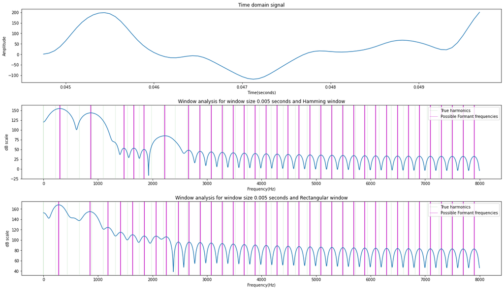

```python
fig = plt.figure()
plt.subplot(311)
#plt.plot([i/fs for i in range(10*P-delta, 11*P+ delta)], data[10*P-delta:11*P+ delta])
plt.plot([j/fs for j in range(10*P-delta,11*P+ delta)], data[0:int(windowSize[0]*fs)])
plt.title("Time domain signal")
plt.xlabel("Time(seconds)")
plt.ylabel("Amplitude")


plt.tight_layout(pad = 1.1)
plt.subplot(312)
fig.set_figheight(10)
fig.set_figwidth(18)
#plt.axvline(300, c= 'r', linestyle = '-', alpha = 0.4)
vlines = [i*F0 for i in range(0, int(fs/(2*F0)))]
magMaxh = scipy.signal.find_peaks(20*np.log(np.abs(windowedDFTh)))[0]*16000/30000
plt.axvline(vlines[0], c = 'g', linewidth = 0.4,alpha = 0.4)
plt.axvline(magMaxh[0], c = 'm', linewidth = 0.5,alpha = 0.9)
for i in vlines:
  plt.axvline(i, c = 'g', linewidth = 0.4,alpha = 0.4)

for i in magMaxh:
  plt.axvline(i, c = 'm')
#plt.plot(freqDFTh, 20*np.log(np.abs(windowedDFTh)))
plt.plot(np.arange(0, fs/2, fs/dftSize[0])[0:], 20*np.log(np.abs(windowedDFTh)))


#plt.axvline(870, c= 'r', linestyle = '-', alpha = 0.4)
#plt.axvline(2240, c= 'r', linestyle = '-', alpha = 0.4)
plt.title(f"Window analysis for window size {windowSize[0]} seconds and Hamming window")
plt.xlabel("Frequency(Hz)")
plt.ylabel("dB scale")
plt.legend(["True harmonics", "Possible Formant frequencies"])
plt.tight_layout(pad = 1.1)

plt.subplot(313)
fig.set_figheight(10)
fig.set_figwidth(18)
#plt.axvline(300, c= 'r', linestyle = '-', alpha = 0.4)
vlines = [i*F0 for i in range(0, int(fs/(2*F0)))]
magMaxr = scipy.signal.find_peaks(20*np.log(np.abs(windowedDFTr)))[0]*16000/30000
plt.axvline(vlines[0], c = 'g', linewidth = 0.4,alpha = 0.4)
plt.axvline(magMaxr[0], c = 'm', linewidth = 0.5,alpha = 0.9)
for i in vlines:
  plt.axvline(i, c = 'g', linewidth = 0.4,alpha = 0.4)

for i in magMaxr:
  plt.axvline(i, c = 'm')
#plt.plot(freqDFTh, 20*np.log(np.abs(windowedDFTh)))
plt.plot(np.arange(0, fs/2, fs/dftSize[0])[0:], 20*np.log(np.abs(windowedDFTr)))


#plt.axvline(870, c= 'r', linestyle = '-', alpha = 0.4)
#plt.axvline(2240, c= 'r', linestyle = '-', alpha = 0.4)
plt.title(f"Window analysis for window size {windowSize[0]} seconds and Rectangular window")
plt.xlabel("Frequency(Hz)")
plt.ylabel("dB scale")
plt.legend(["True harmonics", "Possible Formant frequencies"])
```

```python
#for hamming window we have the following possible formants
(scipy.signal.find_peaks(20*np.log(np.abs(windowedDFTh)))[0]*16000/30000)
```

```
array([ 298.13333333,  867.73333333, 1475.2       , 1658.66666667,
       1845.86666667, 2227.73333333, 2662.4       , 2873.6       ,
       3077.33333333, 3280.        , 3482.13333333, 3683.73333333,
       3885.33333333, 4086.4       , 4287.46666667, 4488.53333333,
       4689.6       , 4890.13333333, 5091.2       , 5291.73333333,
       5492.26666667, 5693.33333333, 5893.86666667, 6094.4       ,
       6294.93333333, 6496.        , 6696.53333333, 6897.06666667,
       7097.6       , 7298.13333333, 7498.66666667, 7699.2       ,
       7899.73333333])
```

From the plot it is clear that :

1. Pitch cannot be estimated since the window is too small and does not see the period
2. F1 = 298.13333333 Hz, F2 = 867.73333333 Hz, F3 = 2227.73333333 Hz

```python
#for rectangular window we have the following possible formants
(scipy.signal.find_peaks(20*np.log(np.abs(windowedDFTr)))[0]*16000/30000)
```

```
array([ 280.        ,  851.73333333, 1180.26666667, 1415.46666667,
       1635.2       , 1848.53333333, 2066.66666667, 2251.73333333,
       2474.13333333, 2672.53333333, 2874.66666667, 3076.8       ,
       3279.46666667, 3481.6       , 3683.2       , 3884.8       ,
       4086.4       , 4287.46666667, 4488.53333333, 4689.6       ,
       4890.13333333, 5091.2       , 5291.73333333, 5492.8       ,
       5693.33333333, 5893.86666667, 6094.4       , 6295.46666667,
       6496.        , 6696.53333333, 6897.06666667, 7097.6       ,
       7298.13333333, 7498.66666667, 7699.2       , 7899.73333333])
```

From the plot it is clear that :

1. Pitch cannot be estimated since the window is too small and does not see the period
2. F1 = 280. Hz, F2 = 851.73333333 Hz, F3 = 2066.66666667 Hz

### 10ms rectangular and Hamming window @220 Hz

```python
i = 1
delta = (int(windowSize[i]*fs) - P)//2
#sampling the signal at the centre of the period
dataWindowedh = data[10*P-delta:11*P+ delta]*np.hamming(int(windowSize[i]*fs)) #choosing the hamming window
#dataWindowedh = np.append(dataWindowedh, np.zeros(shape = dftSize[i] - dataWindowedh.shape[0]))
#windowedDFT = computeDFT(dataWindowed, dftSize[i])#the numpy implementation is much faster and hence i use that
#windowedDFT = np.abs(windowedDFT)
windowedDFTh = np.abs(np.fft.fft(dataWindowedh, dftSize[i]))[:dftSize[i]//2]
```

```python
dataWindowedr = data[10*P-delta:11*P+ delta] #choosing the rectangular window
#dataWindowedr = np.append(dataWindowedr, np.zeros(shape = dftSize[i] - dataWindowedr.shape[0]))
#windowedDFT = computeDFT(dataWindowed, dftSize[i])#the numpy implementation is much faster and hence i use that
#windowedDFT = np.abs(windowedDFT)
windowedDFTr = np.abs(np.fft.fft(dataWindowedr, dftSize[i]))[:dftSize[i]//2]#finding the fft of the windowed signal
```

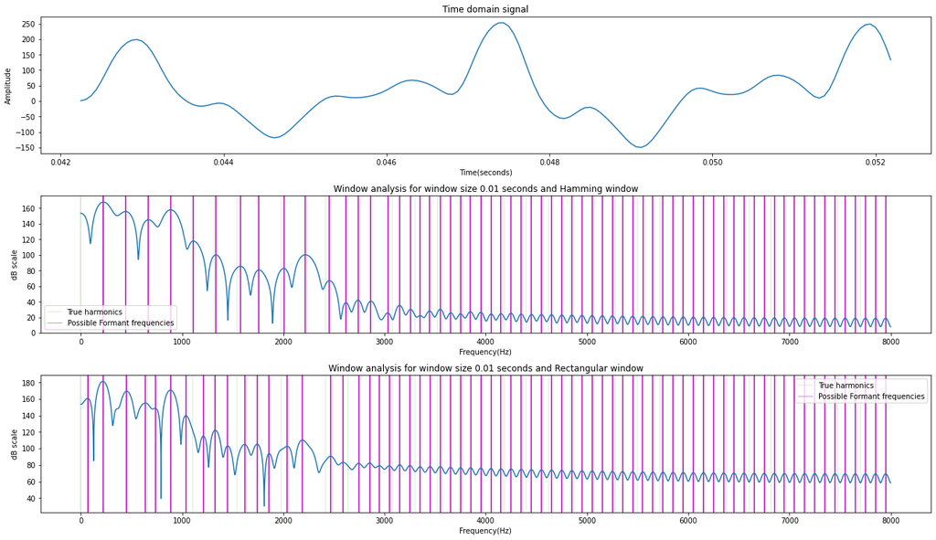

```python
fig = plt.figure()
plt.subplot(311)
#plt.plot([i/fs for i in range(10*P-delta, 11*P+ delta)], data[10*P-delta:11*P+ delta])
plt.plot([j/fs for j in range(10*P-delta,11*P+ delta)], data[0:int(windowSize[1]*fs)])
plt.title("Time domain signal")
plt.xlabel("Time(seconds)")
plt.ylabel("Amplitude")


plt.tight_layout(pad = 1.1)
plt.subplot(312)
fig.set_figheight(10)
fig.set_figwidth(18)
#plt.axvline(300, c= 'r', linestyle = '-', alpha = 0.4)
vlines = [i*F0 for i in range(0, int(fs/(2*F0)))]
magMaxh = scipy.signal.find_peaks(20*np.log(np.abs(windowedDFTh)))[0]*16000/30000
plt.axvline(vlines[0], c = 'g', linewidth = 0.4,alpha = 0.4)
plt.axvline(magMaxh[0], c = 'm', linewidth = 0.5,alpha = 0.9)
for i in vlines:
  plt.axvline(i, c = 'g', linewidth = 0.4,alpha = 0.4)

for i in magMaxh:
  plt.axvline(i, c = 'm')
#plt.plot(freqDFTh, 20*np.log(np.abs(windowedDFTh)))
plt.plot(np.arange(0, fs/2, fs/dftSize[1])[0:], 20*np.log(np.abs(windowedDFTh)))


#plt.axvline(870, c= 'r', linestyle = '-', alpha = 0.4)
#plt.axvline(2240, c= 'r', linestyle = '-', alpha = 0.4)
plt.title(f"Window analysis for window size {windowSize[1]} seconds and Hamming window")
plt.xlabel("Frequency(Hz)")
plt.ylabel("dB scale")
plt.legend(["True harmonics", "Possible Formant frequencies"])
plt.tight_layout(pad = 1.1)

plt.subplot(313)
fig.set_figheight(10)
fig.set_figwidth(18)
#plt.axvline(300, c= 'r', linestyle = '-', alpha = 0.4)
vlines = [i*F0 for i in range(0, int(fs/(2*F0)))]
magMaxr = scipy.signal.find_peaks(20*np.log(np.abs(windowedDFTr)))[0]*16000/30000
plt.axvline(vlines[0], c = 'g', linewidth = 0.4,alpha = 0.4)
plt.axvline(magMaxr[0], c = 'm', linewidth = 0.5,alpha = 0.9)
for i in vlines:
  plt.axvline(i, c = 'g', linewidth = 0.4,alpha = 0.4)

for i in magMaxr:
  plt.axvline(i, c = 'm')
#plt.plot(freqDFTh, 20*np.log(np.abs(windowedDFTh)))
plt.plot(np.arange(0, fs/2, fs/dftSize[1])[0:], 20*np.log(np.abs(windowedDFTr)))


#plt.axvline(870, c= 'r', linestyle = '-', alpha = 0.4)
#plt.axvline(2240, c= 'r', linestyle = '-', alpha = 0.4)
plt.title(f"Window analysis for window size {windowSize[1]} seconds and Rectangular window")
plt.xlabel("Frequency(Hz)")
plt.ylabel("dB scale")
plt.legend(["True harmonics", "Possible Formant frequencies"])
```

```python
#for hamming window we have the following possible formants
(scipy.signal.find_peaks(20*np.log(np.abs(windowedDFTh)))[0]*16000/30000)
```

```
array([ 222.4       ,  442.66666667,  668.26666667,  887.46666667,
       1111.46666667, 1334.4       , 1576.        , 1760.        ,
       2004.8       , 2217.6       , 2456.        , 2618.13333333,
       2738.13333333, 2865.06666667, 3032.        , 3147.73333333,
       3257.06666667, 3351.46666667, 3444.8       , 3549.86666667,
       3653.86666667, 3750.93333333, 3848.        , 3950.4       ,
       4052.8       , 4150.4       , 4249.06666667, 4350.93333333,
       4451.73333333, 4550.4       , 4649.6       , 4750.93333333,
       4851.2       , 4950.4       , 5050.13333333, 5150.93333333,
       5250.66666667, 5350.4       , 5450.66666667, 5550.93333333,
       5650.66666667, 5750.4       , 5850.66666667, 5950.4       ,
       6050.66666667, 6150.4       , 6250.13333333, 6350.4       ,
       6450.13333333, 6550.4       , 6650.13333333, 6750.4       ,
       6850.13333333, 6950.4       , 7050.13333333, 7150.4       ,
       7250.13333333, 7350.4       , 7450.13333333, 7549.86666667,
       7650.13333333, 7749.86666667, 7850.13333333, 7949.86666667])
```

```python
#for rectangular window we have the following possible formants
(scipy.signal.find_peaks(20*np.log(np.abs(windowedDFTr)))[0]*16000/30000)
```

```
array([  67.73333333,  217.06666667,  452.8       ,  637.33333333,
        736.        ,  884.8       , 1037.33333333, 1210.66666667,
       1327.46666667, 1450.66666667, 1617.06666667, 1741.33333333,
       1860.8       , 2039.46666667, 2187.73333333, 2467.73333333,
       2591.46666667, 2744.53333333, 2852.8       , 2949.33333333,
       3046.93333333, 3148.8       , 3250.66666667, 3350.4       ,
       3449.6       , 3549.86666667, 3650.66666667, 3750.4       ,
       3850.13333333, 3950.4       , 4050.66666667, 4150.4       ,
       4250.66666667, 4350.93333333, 4450.66666667, 4550.4       ,
       4650.66666667, 4750.93333333, 4850.66666667, 4950.4       ,
       5050.66666667, 5150.4       , 5250.66666667, 5350.4       ,
       5450.66666667, 5550.4       , 5650.66666667, 5750.4       ,
       5850.66666667, 5950.4       , 6050.66666667, 6150.4       ,
       6250.66666667, 6350.4       , 6450.13333333, 6550.4       ,
       6650.13333333, 6750.4       , 6850.13333333, 6950.4       ,
       7050.13333333, 7150.4       , 7250.13333333, 7350.4       ,
       7450.13333333, 7549.86666667, 7650.13333333, 7749.86666667,
       7850.13333333, 7949.86666667])
```

From the plot it is clear that :

### 20ms rectangular and Hamming window @220 Hz

```python
i = 2
delta = (int(windowSize[i]*fs) - P)//2
#sampling the signal at the centre of the period
dataWindowedh = data[10*P-delta:11*P+ delta]*np.hamming(int(windowSize[i]*fs)) #choosing the hamming window
#dataWindowedh = np.append(dataWindowedh, np.zeros(shape = dftSize[i] - dataWindowedh.shape[0]))
#windowedDFT = computeDFT(dataWindowed, dftSize[i])#the numpy implementation is much faster and hence i use that
#windowedDFT = np.abs(windowedDFT)
windowedDFTh = np.abs(np.fft.fft(dataWindowedh, dftSize[i]))[:dftSize[i]//2]
```

```python
dataWindowedr = data[10*P-delta:11*P+ delta] #choosing the rectangular window
#dataWindowedr = np.append(dataWindowedr, np.zeros(shape = dftSize[i] - dataWindowedr.shape[0]))
#windowedDFT = computeDFT(dataWindowed, dftSize[i])#the numpy implementation is much faster and hence i use that
#windowedDFT = np.abs(windowedDFT)
windowedDFTr = np.abs(np.fft.fft(dataWindowedr, dftSize[i]))[:dftSize[i]//2]#finding the fft of the windowed signal
```

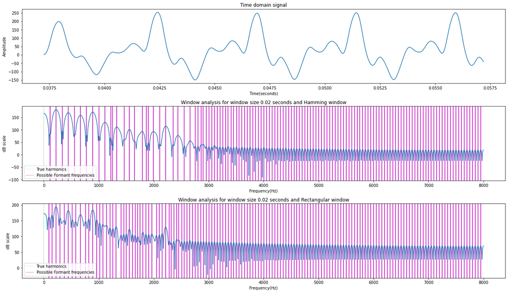

```python
fig = plt.figure()
plt.subplot(311)
#plt.plot([i/fs for i in range(10*P-delta, 11*P+ delta)], data[10*P-delta:11*P+ delta])
plt.plot([j/fs for j in range(10*P-delta, 11*P+ delta)], data[0:int(windowSize[2]*fs)])
plt.title("Time domain signal")
plt.xlabel("Time(seconds)")
plt.ylabel("Amplitude")


plt.tight_layout(pad = 1.1)
plt.subplot(312)
fig.set_figheight(10)
fig.set_figwidth(18)
#plt.axvline(300, c= 'r', linestyle = '-', alpha = 0.4)
vlines = [i*F0 for i in range(0, int(fs/(2*F0)))]
magMaxh = scipy.signal.find_peaks(20*np.log(np.abs(windowedDFTh)))[0]*16000/30000
plt.axvline(vlines[0], c = 'g', linewidth = 0.4,alpha = 0.4)
plt.axvline(magMaxh[0], c = 'm', linewidth = 0.5,alpha = 0.9)
for i in vlines:
  plt.axvline(i, c = 'g', linewidth = 0.4,alpha = 0.4)

for i in magMaxh:
  plt.axvline(i, c = 'm')
#plt.plot(freqDFTh, 20*np.log(np.abs(windowedDFTh)))
plt.plot(np.arange(0, fs/2, fs/dftSize[2])[0:], 20*np.log(np.abs(windowedDFTh)))


#plt.axvline(870, c= 'r', linestyle = '-', alpha = 0.4)
#plt.axvline(2240, c= 'r', linestyle = '-', alpha = 0.4)
plt.title(f"Window analysis for window size {windowSize[2]} seconds and Hamming window")
plt.xlabel("Frequency(Hz)")
plt.ylabel("dB scale")
plt.legend(["True harmonics", "Possible Formant frequencies"])
plt.tight_layout(pad = 1.1)

plt.subplot(313)
fig.set_figheight(10)
fig.set_figwidth(18)
#plt.axvline(300, c= 'r', linestyle = '-', alpha = 0.4)
vlines = [i*F0 for i in range(0, int(fs/(2*F0)))]
magMaxr = scipy.signal.find_peaks(20*np.log(np.abs(windowedDFTr)))[0]*16000/30000
plt.axvline(vlines[0], c = 'g', linewidth = 0.4,alpha = 0.4)
plt.axvline(magMaxr[0], c = 'm', linewidth = 0.5,alpha = 0.9)
for i in vlines:
  plt.axvline(i, c = 'g', linewidth = 0.4,alpha = 0.4)

for i in magMaxr:
  plt.axvline(i, c = 'm')
#plt.plot(freqDFTh, 20*np.log(np.abs(windowedDFTh)))
plt.plot(np.arange(0, fs/2, fs/dftSize[2])[0:], 20*np.log(np.abs(windowedDFTr)))


#plt.axvline(870, c= 'r', linestyle = '-', alpha = 0.4)
#plt.axvline(2240, c= 'r', linestyle = '-', alpha = 0.4)
plt.title(f"Window analysis for window size {windowSize[2]} seconds and Rectangular window")
plt.xlabel("Frequency(Hz)")
plt.ylabel("dB scale")
plt.legend(["True harmonics", "Possible Formant frequencies"])
```

```python
#for hamming window we have the following possible formants
(scipy.signal.find_peaks(20*np.log(np.abs(windowedDFTh)))[0]*16000/30000)
```

```
array([ 111.46666667,  221.86666667,  334.4       ,  444.26666667,
        559.46666667,  666.66666667,  776.53333333,  888.53333333,
       1001.6       , 1111.46666667, 1214.93333333, 1246.93333333,
       1324.26666667, 1459.73333333, 1556.26666667, 1650.66666667,
       1789.33333333, 1865.06666667, 1902.4       , 1992.        ,
       2106.13333333, 2219.73333333, 2350.93333333, 2441.6       ,
       2556.8       , 2660.26666667, 2754.66666667, 2805.86666667,
       2861.33333333, 2901.33333333, 2954.13333333, 3005.33333333,
       3055.46666667, 3105.6       , 3153.6       , 3204.8       ,
       3254.93333333, 3304.53333333, 3353.6       , 3404.8       ,
       3454.4       , 3505.06666667, 3554.13333333, 3603.2       ,
       3653.86666667, 3703.46666667, 3754.66666667, 3804.26666667,
       3853.33333333, 3903.46666667, 3953.06666667, 4003.73333333,
       4053.86666667, 4103.46666667, 4153.6       , 4203.2       ,
       4252.8       , 4303.46666667, 4353.06666667, 4403.2       ,
       4453.33333333, 4502.93333333, 4553.06666667, 4602.66666667,
       4652.8       , 4702.93333333, 4752.53333333, 4802.66666667,
       4852.26666667, 4902.4       , 4952.53333333, 5002.66666667,
       5052.26666667, 5102.4       , 5152.        , 5202.13333333,
       5252.26666667, 5302.4       , 5352.        , 5402.13333333,
       5452.26666667, 5501.86666667, 5552.        , 5602.13333333,
       5651.73333333, 5701.86666667, 5751.46666667, 5801.6       ,
       5851.73333333, 5901.86666667, 5951.46666667, 6001.6       ,
       6051.73333333, 6101.33333333, 6151.46666667, 6201.6       ,
       6251.2       , 6301.33333333, 6351.46666667, 6401.06666667,
       6451.2       , 6501.33333333, 6550.93333333, 6601.06666667,
       6651.2       , 6700.8       , 6750.93333333, 6801.06666667,
       6850.66666667, 6900.8       , 6950.93333333, 7000.53333333,
       7050.66666667, 7100.8       , 7150.4       , 7200.53333333,
       7250.66666667, 7300.26666667, 7350.4       , 7400.53333333,
       7450.66666667, 7500.26666667, 7550.4       , 7600.53333333,
       7650.13333333, 7700.26666667, 7750.4       , 7800.        ,
       7850.13333333, 7900.26666667, 7949.86666667])
```

From the plot it is clear that :

1. Pitch can be estimated since the window is large enought see the period F0 ~ 200 Hz (5 major peaks from 1000Hz to 2000Hz )
2. F1 = 221.86666667 Hz, F2 = 888.53333333 Hz, F3 = 2219.73333333 Hz

```python
#for rectangular window we have the following possible formants
(scipy.signal.find_peaks(20*np.log(np.abs(windowedDFTr)))[0]*16000/30000)
```

```
array([  92.26666667,  147.73333333,  220.26666667,  293.86666667,
        371.73333333,  444.8       ,  517.86666667,  576.        ,
        666.13333333,  758.93333333,  815.46666667,  888.53333333,
        961.06666667, 1013.86666667, 1071.46666667, 1137.06666667,
       1203.73333333, 1256.        , 1313.6       , 1404.8       ,
       1452.8       , 1500.8       , 1556.26666667, 1612.26666667,
       1660.26666667, 1708.8       , 1749.33333333, 1801.06666667,
       1856.53333333, 1908.26666667, 1963.73333333, 2048.53333333,
       2101.33333333, 2152.        , 2216.        , 2282.13333333,
       2317.86666667, 2363.73333333, 2418.13333333, 2454.4       ,
       2507.73333333, 2556.8       , 2606.4       , 2656.53333333,
       2706.66666667, 2756.26666667, 2805.86666667, 2856.        ,
       2905.06666667, 2955.2       , 3005.33333333, 3054.93333333,
       3105.06666667, 3155.2       , 3204.8       , 3254.93333333,
       3304.53333333, 3354.66666667, 3404.26666667, 3454.4       ,
       3504.53333333, 3554.13333333, 3603.73333333, 3653.86666667,
       3704.        , 3754.13333333, 3803.73333333, 3853.86666667,
       3903.46666667, 3953.6       , 4003.73333333, 4053.33333333,
       4103.46666667, 4153.6       , 4203.2       , 4253.33333333,
       4302.93333333, 4353.06666667, 4403.2       , 4452.8       ,
       4502.93333333, 4553.06666667, 4602.66666667, 4652.8       ,
       4702.93333333, 4752.53333333, 4802.66666667, 4852.8       ,
       4902.4       , 4952.53333333, 5002.66666667, 5052.26666667,
       5102.4       , 5152.53333333, 5202.13333333, 5252.26666667,
       5302.4       , 5352.        , 5402.13333333, 5452.26666667,
       5501.86666667, 5552.        , 5602.13333333, 5651.73333333,
       5701.86666667, 5752.        , 5801.6       , 5851.73333333,
       5901.86666667, 5951.46666667, 6001.6       , 6051.73333333,
       6101.33333333, 6151.46666667, 6201.6       , 6251.2       ,
       6301.33333333, 6351.46666667, 6401.06666667, 6451.2       ,
       6501.33333333, 6550.93333333, 6601.06666667, 6651.2       ,
       6700.8       , 6750.93333333, 6801.06666667, 6850.66666667,
       6900.8       , 6950.93333333, 7000.53333333, 7050.66666667,
       7100.8       , 7150.4       , 7200.53333333, 7250.66666667,
       7300.26666667, 7350.4       , 7400.53333333, 7450.66666667,
       7500.26666667, 7550.4       , 7600.53333333, 7650.13333333,
       7700.26666667, 7750.4       , 7800.        , 7850.13333333,
       7900.26666667, 7949.86666667])
```

From the plot it is clear that :

1. Pitch can be estimated since the window is large enought see the period F0 ~ 250 Hz (4 peaks from 0 Hz to 1000Hz)
2. F1 = 220.26666667 Hz, F2 = 888.5333333 Hz, F3 = 2216. Hz

```python
i = 3
delta = (int(windowSize[i]*fs) - P)//2
#sampling the signal at the centre of the period
dataWindowedh = data[10*P-delta:11*P+ delta]*np.hamming(int(windowSize[i]*fs)) #choosing the hamming window
#dataWindowedh = np.append(dataWindowedh, np.zeros(shape = dftSize[i] - dataWindowedh.shape[0]))
#windowedDFT = computeDFT(dataWindowed, dftSize[i])#the numpy implementation is much faster and hence i use that
#windowedDFT = np.abs(windowedDFT)
windowedDFTh = np.abs(np.fft.fft(dataWindowedh, dftSize[i]))[:dftSize[i]//2]
```

```python
dataWindowedr = data[10*P-delta:11*P+ delta] #choosing the rectangular window
#dataWindowedr = np.append(dataWindowedr, np.zeros(shape = dftSize[i] - dataWindowedr.shape[0]))
#windowedDFT = computeDFT(dataWindowed, dftSize[i])#the numpy implementation is much faster and hence i use that
#windowedDFT = np.abs(windowedDFT)
windowedDFTr = np.abs(np.fft.fft(dataWindowedr, dftSize[i]))[:dftSize[i]//2]#finding the fft of the windowed signal
```

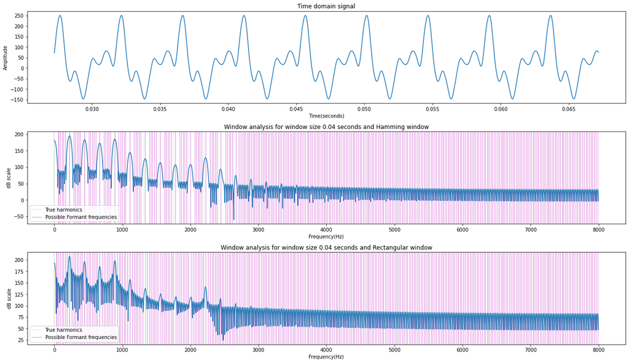

```python
fig = plt.figure()
plt.subplot(311)
#plt.plot([i/fs for i in range(10*P-delta, 11*P+ delta)], data[10*P-delta:11*P+ delta])
plt.plot([j/fs for j in range(10*P-delta, 11*P+ delta)], data[10*P-delta:11*P+ delta])
plt.title("Time domain signal")
plt.xlabel("Time(seconds)")
plt.ylabel("Amplitude")


plt.tight_layout(pad = 1.1)
plt.subplot(312)
fig.set_figheight(10)
fig.set_figwidth(18)
#plt.axvline(300, c= 'r', linestyle = '-', alpha = 0.4)
vlines = [i*F0 for i in range(0, int(fs/(2*F0)))]
magMaxh = scipy.signal.find_peaks(20*np.log(np.abs(windowedDFTh)))[0]*16000/30000
plt.axvline(vlines[0], c = 'g', linewidth = 0.4,alpha = 0.4)
plt.axvline(magMaxh[0], c = 'm', linewidth = 0.5,alpha = 0.9)
for i in vlines:
  plt.axvline(i, c = 'g', linewidth = 0.4,alpha = 0.4)

for i in magMaxh:
  plt.axvline(i, c = 'm', linewidth = 0.5,alpha = 0.9)
#plt.plot(freqDFTh, 20*np.log(np.abs(windowedDFTh)))
plt.plot(np.arange(0, fs/2, fs/dftSize[3])[0:], 20*np.log(np.abs(windowedDFTh)))


#plt.axvline(870, c= 'r', linestyle = '-', alpha = 0.4)
#plt.axvline(2240, c= 'r', linestyle = '-', alpha = 0.4)
plt.title(f"Window analysis for window size {windowSize[3]} seconds and Hamming window")
plt.xlabel("Frequency(Hz)")
plt.ylabel("dB scale")
plt.legend(["True harmonics", "Possible Formant frequencies"])
plt.tight_layout(pad = 1.1)

plt.subplot(313)
fig.set_figheight(10)
fig.set_figwidth(18)
#plt.axvline(300, c= 'r', linestyle = '-', alpha = 0.4)
vlines = [i*F0 for i in range(0, int(fs/(2*F0)))]
magMaxr = scipy.signal.find_peaks(20*np.log(np.abs(windowedDFTr)))[0]*16000/30000
plt.axvline(vlines[0], c = 'g', linewidth = 0.4,alpha = 0.4)
plt.axvline(magMaxr[0], c = 'm', linewidth = 0.5,alpha = 0.9)
for i in vlines:
  plt.axvline(i, c = 'g', linewidth = 0.4,alpha = 0.4)

for i in magMaxr:
  plt.axvline(i, c = 'm', linewidth = 0.5,alpha = 0.9)
#plt.plot(freqDFTh, 20*np.log(np.abs(windowedDFTh)))
plt.plot(np.arange(0, fs/2, fs/dftSize[3])[0:], 20*np.log(np.abs(windowedDFTr)))


#plt.axvline(870, c= 'r', linestyle = '-', alpha = 0.4)
#plt.axvline(2240, c= 'r', linestyle = '-', alpha = 0.4)
plt.title(f"Window analysis for window size {windowSize[3]} seconds and Rectangular window")
plt.xlabel("Frequency(Hz)")
plt.ylabel("dB scale")
plt.legend(["True harmonics", "Possible Formant frequencies"])
```

```python
#for hamming window we have the following possible formants
(scipy.signal.find_peaks(20*np.log(np.abs(windowedDFTh)))[0]*16000/30000)
```

```
array([  59.2       ,   86.93333333,  111.46666667,  136.53333333,
        164.26666667,  222.4       ,  287.46666667,  309.33333333,
        333.86666667,  358.4       ,  381.86666667,  443.73333333,
        505.06666667,  531.73333333,  556.8       ,  581.33333333,
        605.86666667,  666.66666667,  729.06666667,  753.06666667,
        778.13333333,  802.13333333,  823.46666667,  888.53333333,
        946.13333333,  973.86666667,  998.4       , 1022.93333333,
       1048.53333333, 1111.46666667, 1171.2       , 1196.26666667,
       1221.33333333, 1245.86666667, 1271.46666667, 1334.4       ,
       1394.66666667, 1419.73333333, 1444.26666667, 1469.33333333,
       1494.93333333, 1557.33333333, 1618.13333333, 1643.2       ,
       1667.73333333, 1692.8       , 1718.4       , 1779.73333333,
       1842.13333333, 1866.66666667, 1891.73333333, 1916.8       ,
       1941.86666667, 2001.6       , 2065.6       , 2090.13333333,
       2115.2       , 2140.26666667, 2166.4       , 2221.86666667,
       2290.13333333, 2315.73333333, 2340.26666667, 2365.33333333,
       2391.46666667, 2442.66666667, 2515.73333333, 2540.8       ,
       2565.86666667, 2590.93333333, 2616.53333333, 2666.13333333,
       2714.66666667, 2740.8       , 2765.86666667, 2790.4       ,
       2815.46666667, 2841.06666667, 2862.93333333, 2890.13333333,
       2918.4       , 2940.26666667, 2965.33333333, 2990.4       ,
       3015.46666667, 3040.        , 3065.6       , 3088.53333333,
       3114.66666667, 3141.33333333, 3164.8       , 3189.86666667,
       3214.93333333, 3240.        , 3265.06666667, 3290.13333333,
       3314.13333333, 3339.2       , 3365.33333333, 3389.86666667,
       3414.93333333, 3439.46666667, 3464.53333333, 3489.6       ,
       3514.66666667, 3539.2       , 3563.73333333, 3589.86666667,
       3614.4       , 3639.46666667, 3664.53333333, 3689.6       ,
       3714.66666667, 3739.73333333, 3764.26666667, 3788.8       ,
       3814.4       , 3839.46666667, 3864.53333333, 3889.06666667,
       3914.13333333, 3939.2       , 3964.26666667, 3989.33333333,
       4013.86666667, 4039.46666667, 4064.        , 4089.06666667,
       4114.13333333, 4139.2       , 4164.26666667, 4188.8       ,
       4213.86666667, 4238.93333333, 4264.        , 4289.06666667,
       4314.13333333, 4338.66666667, 4363.73333333, 4388.8       ,
       4413.86666667, 4438.93333333, 4464.        , 4489.06666667,
       4513.6       , 4538.66666667, 4563.73333333, 4588.8       ,
       4613.86666667, 4638.93333333, 4664.        , 4688.53333333,
       4713.6       , 4738.66666667, 4763.73333333, 4788.8       ,
       4813.86666667, 4838.4       , 4863.46666667, 4888.53333333,
```

[output cut: 16 more lines]

```
       6513.06666667, 6538.13333333, 6563.2       , 6587.73333333,
       6612.8       , 6637.86666667, 6662.93333333, 6688.        ,
       6713.06666667, 6738.13333333, 6762.66666667, 6787.73333333,
       6812.8       , 6837.86666667, 6862.93333333, 6888.        ,
       6913.06666667, 6937.6       , 6962.66666667, 6987.73333333,
       7012.8       , 7037.86666667, 7062.93333333, 7088.        ,
       7112.53333333, 7137.6       , 7162.66666667, 7187.73333333,
       7212.8       , 7237.86666667, 7262.93333333, 7287.46666667,
       7312.53333333, 7337.6       , 7362.66666667, 7387.73333333,
       7412.8       , 7437.86666667, 7462.4       , 7487.46666667,
       7512.53333333, 7537.6       , 7562.66666667, 7587.73333333,
       7612.8       , 7637.86666667, 7662.4       , 7687.46666667,
       7712.53333333, 7737.6       , 7762.66666667, 7787.73333333,
       7812.8       , 7837.33333333, 7862.4       , 7887.46666667,
       7912.53333333, 7937.6       , 7962.66666667, 7987.73333333])
```

```python
#for rectangular window we have the following possible formants
(scipy.signal.find_peaks(20*np.log(np.abs(windowedDFTr)))[0]*16000/30000)
```

```
array([  35.73333333,   61.33333333,   86.93333333,  111.46666667,
        136.        ,  161.6       ,  187.2       ,  222.93333333,
        258.13333333,  283.73333333,  308.8       ,  333.86666667,
        358.4       ,  383.46666667,  409.06666667,  442.66666667,
        478.93333333,  505.06666667,  530.66666667,  556.26666667,
        581.86666667,  606.4       ,  632.        ,  666.66666667,
        701.86666667,  727.46666667,  753.06666667,  778.13333333,
        803.2       ,  828.26666667,  853.33333333,  888.53333333,
        924.26666667,  949.33333333,  974.4       ,  998.93333333,
       1023.46666667, 1048.        , 1073.06666667, 1113.6       ,
       1147.2       , 1172.26666667, 1197.33333333, 1221.86666667,
       1245.86666667, 1270.4       , 1294.4       , 1338.66666667,
       1370.66666667, 1395.2       , 1420.26666667, 1444.8       ,
       1469.33333333, 1493.33333333, 1517.33333333, 1563.73333333,
       1593.6       , 1618.66666667, 1643.2       , 1668.26666667,
       1692.8       , 1717.33333333, 1741.33333333, 1787.73333333,
       1817.06666667, 1842.13333333, 1866.66666667, 1891.73333333,
       1916.26666667, 1940.8       , 1964.8       , 2010.13333333,
       2040.        , 2065.06666667, 2090.13333333, 2114.66666667,
       2138.66666667, 2163.2       , 2187.2       , 2221.33333333,
       2260.8       , 2289.06666667, 2314.66666667, 2340.26666667,
       2364.8       , 2389.86666667, 2414.4       , 2441.6       ,
       2468.8       , 2492.26666667, 2516.8       , 2541.33333333,
       2565.86666667, 2590.93333333, 2615.46666667, 2640.        ,
       2666.13333333, 2691.73333333, 2716.26666667, 2740.8       ,
       2765.86666667, 2790.4       , 2815.46666667, 2840.        ,
       2865.06666667, 2890.13333333, 2915.73333333, 2940.8       ,
       2965.33333333, 2990.4       , 3015.46666667, 3040.        ,
       3065.06666667, 3089.6       , 3114.66666667, 3140.26666667,
       3165.33333333, 3189.86666667, 3214.93333333, 3240.        ,
       3265.06666667, 3289.6       , 3314.66666667, 3339.73333333,
       3364.8       , 3389.86666667, 3414.93333333, 3439.46666667,
       3464.53333333, 3489.6       , 3514.66666667, 3539.2       ,
       3564.26666667, 3589.33333333, 3614.4       , 3639.46666667,
       3664.53333333, 3689.6       , 3714.66666667, 3739.2       ,
       3764.26666667, 3789.33333333, 3814.4       , 3839.46666667,
       3864.53333333, 3889.06666667, 3914.13333333, 3939.2       ,
       3964.26666667, 3989.33333333, 4013.86666667, 4038.93333333,
       4064.        , 4089.06666667, 4114.13333333, 4139.2       ,
       4164.26666667, 4188.8       , 4213.86666667, 4238.93333333,
```

[output cut: 23 more lines]

```
       6563.2       , 6587.73333333, 6612.8       , 6637.86666667,
       6662.93333333, 6688.        , 6713.06666667, 6738.13333333,
       6762.66666667, 6787.73333333, 6812.8       , 6837.86666667,
       6862.93333333, 6888.        , 6913.06666667, 6937.6       ,
       6962.66666667, 6987.73333333, 7012.8       , 7037.86666667,
       7062.93333333, 7088.        , 7112.53333333, 7137.6       ,
       7162.66666667, 7187.73333333, 7212.8       , 7237.86666667,
       7262.93333333, 7287.46666667, 7312.53333333, 7337.6       ,
       7362.66666667, 7387.73333333, 7412.8       , 7437.86666667,
       7462.4       , 7487.46666667, 7512.53333333, 7537.6       ,
       7562.66666667, 7587.73333333, 7612.8       , 7637.86666667,
       7662.4       , 7687.46666667, 7712.53333333, 7737.6       ,
       7762.66666667, 7787.73333333, 7812.8       , 7837.33333333,
       7862.4       , 7887.46666667, 7912.53333333, 7937.6       ,
       7962.66666667, 7987.73333333])
```

From the plot it is clear that :

1. Pitch can be estimated since the window is large enought see the period F0 ~ 200 Hz[5 major peaks in the 1000 Hz to 2000Hz range]
2. F1 = 222.93333333 Hz, F2 = 888.53333333 Hz, F3 = 2187.2 Hz

*We would like to use the DFT computed with various window lengths and shapes to estimate the vowel’s F0 and formant frequencies and study the obtained accuracies with reference to our ‘ground truth’ values.*

*For the analysis, use a single waveform segment near the centre of your synthesized vowel. Plot the magnitude (dB) spectrum with rectangular and Hamming windows of lengths: 5 ms, 10 ms, 20 ms, 40 ms, each with a large zero-padded DFT. (i) Comment on the similarities and differences between the different computed spectra. (ii) Estimate the signal parameters from each of the magnitude spectra and report the error with respect to the ground-truth.*

Part (i)

1. We observe that when the window size increase the Pitch estimation becomes better since the window can see many periods of the signal compared to smaller windows.
2. As window size increases the estimation of formants becomes worse since we are not able to distinguish between the peaks of the pitch and the formants [i.e hidden envelope is difficult to see]
3. As we shift from narrowband to wideband spectra we observe that the magnitude plot becomes smoother since a smaller window is not able to estimate pitch as well and thus has less of the pitch related harmonics.
4. Rectangular windows have a much more rougher oscillations compared to hamming window. This is due to the fact that Hamming window is tapered compared to the rectangular window.
5. As we decrease F0, the estimation of the formant frequencies and the pitch become better(provided we are able to choose the correct window size)

Part (ii)

I have added the estimates in the individual sections.

We observe the following:

1. For better pitch estimation, we would prefer larger window sizes
2. For better formant estimation, smaller windows are better.
3. At lower F0, we are able to get a better estimates for the formants than at higher F0.

## Difficulties faced:

1. Pitch estimation was hard since the peaks were difficult to count so had to resort to count the peaks in a particular range of frequencies.
2. Envelope is also difficult to imagine in case of larger windows. Hence the estimated formant frequencies are taken assuming a envelope based off the dB plots. In many cases F3 peaks are just slighly larger than the surrounding peaks and hence it was difficult to spot them.